# STAT408_HW2

2022-09-26

# Question 1

(10 points). Consider a simple linear regression model y = $beta_0$ +$beta_1$x + $epsilon$. We fit this model based on a dataset with test score (y) and training hours (x). The fitted model is y = 10 + 0.56x.

## part (a)

What is the fitted value of the response variable corresponding to x = 7?

```r
y_fit <- 10 + 0.56*7
y_fit
```

```
## [1] 13.92
```

## part (b)

What is the residual corresponding to the data point with x = 7 and y = 17

```r
13.92-17
```

```
## [1] -3.08
```

## part (c)

If the number of training hours is increased by 1, how is the expected test score affected?

The expected test score increases by 0.56 when the number of training hours is increased by 1.

## part (d)

Consider the data point in part b. An additional test score is to be obtained for a new observation at x = 7. Would the test score for the new observation necessarily be 17? Explain.

No, the new observation for the test score at x = 7 does not necessarily have to be equal to 17 because these are real world observations that do not follow a strict pattern and may be outliers.

# Question 2

(10 points) In this question, we will still use the teengamb dataset. It concerns a study of teenage gambling in Britain. Each row is one teenager’s records. Download this dataset from Sakai and read it into R.

## part (a)

```r
teengamb <- read.csv("teengamb.csv")
```

## part (a)

Fit a regression model with the expenditure on gambling as the response and the sex, status, income and verbal score as predictors. Save the model output to a “model” object. Use the summary function to show the model output.

```r
model <- lm(gamble ~ sex + status + income + verbal, data = teengamb)
summary(model)
```

```
##
## Call:
## lm(formula = gamble ~ sex + status + income + verbal, data = teengamb)
##
## Residuals:
##     Min      1Q  Median      3Q     Max
## -51.082 -11.320  -1.451   9.452  94.252
##
## Coefficients:
##              Estimate Std. Error t value Pr(>|t|)
## (Intercept)  22.55565   17.19680   1.312   0.1968
## sex         -22.11833    8.21111  -2.694   0.0101 *
## status        0.05223    0.28111   0.186   0.8535
## income        4.96198    1.02539   4.839 1.79e-05 ***
## verbal       -2.95949    2.17215  -1.362   0.1803
## ---
## Signif. codes:  0 '***' 0.001 '**' 0.01 '*' 0.05 '.' 0.1 ' ' 1
##
## Residual standard error: 22.69 on 42 degrees of freedom
## Multiple R-squared:  0.5267, Adjusted R-squared:  0.4816
## F-statistic: 11.69 on 4 and 42 DF,  p-value: 1.815e-06
```

## part (b)

What percentage of variation in the response is explained by these predictors?

## part (c)

Use model$residuals to show the residuals. Which observation has the largest (positive) residual?

```r
model$residuals
```

```
##           1           2           3           4           5           6
##  10.6507430   9.3711318   5.4630298 -17.4957487  29.5194692  -2.9846919
##           7           8           9          10          11          12
##  -7.0242994 -12.3060734   6.8496267 -10.3329505   1.5934936  -3.0958161
##          13          14          15          16          17          18
##   0.1172839   9.5331344   2.8488167  17.2107726 -25.2627227 -27.7998544
##          19          20          21          22          23          24
##  13.1446553 -15.9510624 -16.0041386  -9.5801478 -27.2711657  94.2522174
##          25          26          27          28          29          30
##   0.6993361  -9.1670510 -25.8747696  -8.7455549  -6.8803097 -19.8090866
##          31          32          33          34          35          36
##  10.8793766  15.0599340  11.7462296  -3.5932770 -14.4016736  45.6051264
##          37          38          39          40          41          42
##  20.5472529  11.2429290 -51.0824078   8.8669438  -1.4513921  -3.8361619
##          43          44          45          46          47
##  -4.3831786 -14.8940753   5.4506347   1.4092321   7.1662399
```

Observation 24 has the largest positive residual of 94.2522174.

## part (d)

Use model$fitted.values to show the fitted response. Compute the correlation of the residuals with the fitted response.

```r
model$fitted.values
```

```
##           1           2           3           4           5           6
## -10.6507430  -9.3711318  -5.4630298  24.7957487  -9.9194692   3.0846919
##           7           8           9          10          11          12
##   8.4742994  18.9060734  -5.1496267  10.4329505  -1.4934936   8.4958161
##          13          14          15          16          17          18
##   1.0827161  -5.9331344  -0.4488167 -13.8107726  25.3627227  36.1998544
##          19          20          21          22          23          24
##  -1.1446553  15.9510624  17.0041386  10.7801478  27.3711657  61.7477826
##          25          26          27          28          29          30
##  37.8006639  11.2670510  40.3747696  11.7455549   7.4803097  29.4090866
##          31          32          33          34          35          36
##  77.1206234  38.1400660  78.2537704   6.5932770  28.5016736  24.3948736
##          37          38          39          40          41          42
##  17.9527471  45.9570710  57.0824078  16.1330562   8.3513921  73.5361619
##          43          44          45          46          47
##  17.6831786  15.4940753  32.5493653  12.9907679  12.0337601
```

```r
cor(model$residuals, model$fitted.values)
```

```
## [1] -1.070659e-16
```

## part (e)

Compute the correlation of the residuals with the income.

```r
cor(model$residual, teengamb$income)
```

```
## [1] -7.242382e-17
```

## part (f)

If all other predictors held constant, what would be the difference in predicted expenditure on gambling for a male compared to a female?

If all other predictors remain constant, a male is predicted to spend approximately 22.11833 more pounds on gambling per year than a female.

# Question 3

(10 points) The dataset prostate comes from a study on 97 men with prostate cancer who were due to receive a radical prostatectomy. The description of each variable can be found at https://rafalab.github.io/pages/649/prostate.html. Download and import this dataset from Sakai, answer following questions.

```r
prostate <- read.csv("prostate.csv")
```

## part (a)

Fit a regression model with lpsa as the response and lcavol as the predictor. Show the residual sum of square (RSS) and the $R^2$ of this model (hint: check deviance function for RSS)

```r
lpsa_model <- lm(lpsa ~ lcavol, data = prostate)
deviance(lpsa_model)
```

```
## [1] 58.91476
```

```r
summary(lpsa_model)
```

```
##
## Call:
## lm(formula = lpsa ~ lcavol, data = prostate)
##
## Residuals:
##      Min       1Q   Median       3Q      Max
## -1.67625 -0.41648  0.09859  0.50709  1.89673
##
## Coefficients:
##             Estimate Std. Error t value Pr(>|t|)
## (Intercept)  1.50730    0.12194   12.36   <2e-16 ***
## lcavol       0.71932    0.06819   10.55   <2e-16 ***
## ---
## Signif. codes:  0 '***' 0.001 '**' 0.01 '*' 0.05 '.' 0.1 ' ' 1
##
## Residual standard error: 0.7875 on 95 degrees of freedom
## Multiple R-squared:  0.5394, Adjusted R-squared:  0.5346
## F-statistic: 111.3 on 1 and 95 DF,  p-value: < 2.2e-16
```

## part (b)

Add lweight, svi, lbph, age, lcp, pgg45 and gleason as predictors to the regression model. Show the residual sum of square (RSS) and the $R^2$ of this model.

```r
lpsa_model2 <- lm(lpsa ~ lcavol + lweight + svi + lbph + age + lcp + pgg45 + gleason, data = prostate)
deviance(lpsa_model2)
```

```
## [1] 44.16302
```

```r
summary(lpsa_model2)
```

```
##
## Call:
## lm(formula = lpsa ~ lcavol + lweight + svi + lbph + age + lcp +
##     pgg45 + gleason, data = prostate)
##
## Residuals:
##     Min      1Q  Median      3Q     Max
## -1.7331 -0.3713 -0.0170  0.4141  1.6381
##
## Coefficients:
##              Estimate Std. Error t value Pr(>|t|)
## (Intercept)  0.669337   1.296387   0.516  0.60693
## lcavol       0.587022   0.087920   6.677 2.11e-09 ***
## lweight      0.454467   0.170012   2.673  0.00896 **
## svi          0.766157   0.244309   3.136  0.00233 **
## lbph         0.107054   0.058449   1.832  0.07040 .
## age         -0.019637   0.011173  -1.758  0.08229 .
## lcp         -0.105474   0.091013  -1.159  0.24964
## pgg45        0.004525   0.004421   1.024  0.30886
## gleason      0.045142   0.157465   0.287  0.77503
## ---
## Signif. codes:  0 '***' 0.001 '**' 0.01 '*' 0.05 '.' 0.1 ' ' 1
##
## Residual standard error: 0.7084 on 88 degrees of freedom
## Multiple R-squared:  0.6548, Adjusted R-squared:  0.6234
## F-statistic: 20.86 on 8 and 88 DF,  p-value: < 2.2e-16
```

## part (c)

Compare the RSS and $R^2$ of these two models. Explain why you observe such a comparison result.

## part (d)

Use the method introduced in lecture slides to manually fit the model in b. First construct a design matrix X, then a response vector y, and finally use the formula of parameter estimation. Compare the manually estimated parameters with the result from the lm function.

```r
X <- model.matrix(~ lcavol + lweight + svi + lbph + age + lcp + pgg45 + gleason, data = prostate)
y <- prostate$lpsa
XtXi <- solve(t(X)%*%X)
XtXi%*%t(X)%*%y
```

```
##                     [,1]
## (Intercept)  0.669336698
## lcavol       0.587021826
## lweight      0.454467424
## svi          0.766157326
## lbph         0.107054031
## age         -0.019637176
## lcp         -0.105474263
## pgg45        0.004525231
## gleason      0.045141598
```

The estimated parameters found manually appear to be pretty much identical to those that were found using the lm function in part b.

# Question 4

(10 points) Thirty samples of cheddar cheese were analyzed for their content of acetic acid, hydrogen sulfide and lactic acid. Each sample was tasted and scored by a panel of judges and the average taste score produced. Use the cheddar dataset from Sakai to answer the following questions.

```r
cheddar <- read.csv("cheddar.csv")
```

## part (a)

Fit a regression model with taste as the response and the three chemical contents as predictors. Report the values of the regression coefficients.

```r
cheese_model <- lm(taste ~ Acetic + H2S + Lactic, data = cheddar)
coefficients(cheese_model)
```

```
## (Intercept)      Acetic         H2S      Lactic
## -28.8767696   0.3277413   3.9118411  19.6705434
```

## part (b)

Compute the correlation between the fitted values and the true response. What information can you learn from this correlation?

```r
cor(cheese_model$fitted.values, cheddar$taste)
```

```
## [1] 0.8073256
```

Because this correlation coefficient of 0.8073256 is pretty high, this suggests that there is a strong positive correlation between the fitted values and true response and therefore this model does a decent job of estimating the taste of the cheese.

## part (c)

How do you interpret the value of intercept in this model? Does this value make sense in this setting (tasting cheese)?

The intercept has a value of -28.8767696, which means that if all three chemical contents were equal to zero the expected taste score of the cheese would be -28.8767696. However, this does not necessarily make sense in the context of this problem as the judges on the panel are likely to be scoring the taste of the cheese on a positive scale (such as from 1 to 10).

# Question 5

(10 points) Run the following R code:

```r
set.seed(1234)
x <- runif(100,0,10)
y <- 3+x+x^2+rnorm(100,0,1)

lm1 <- lm(y~x)
lm2 <- lm(y~x+I(x^2))
```

## part (a)

Explain what the code does. Use ?function_name() or Google if you do not know the meaning of any function.

## part (b)

For both models, plot the residual versus the fitted response. Describe the pattern you observed in the plots.

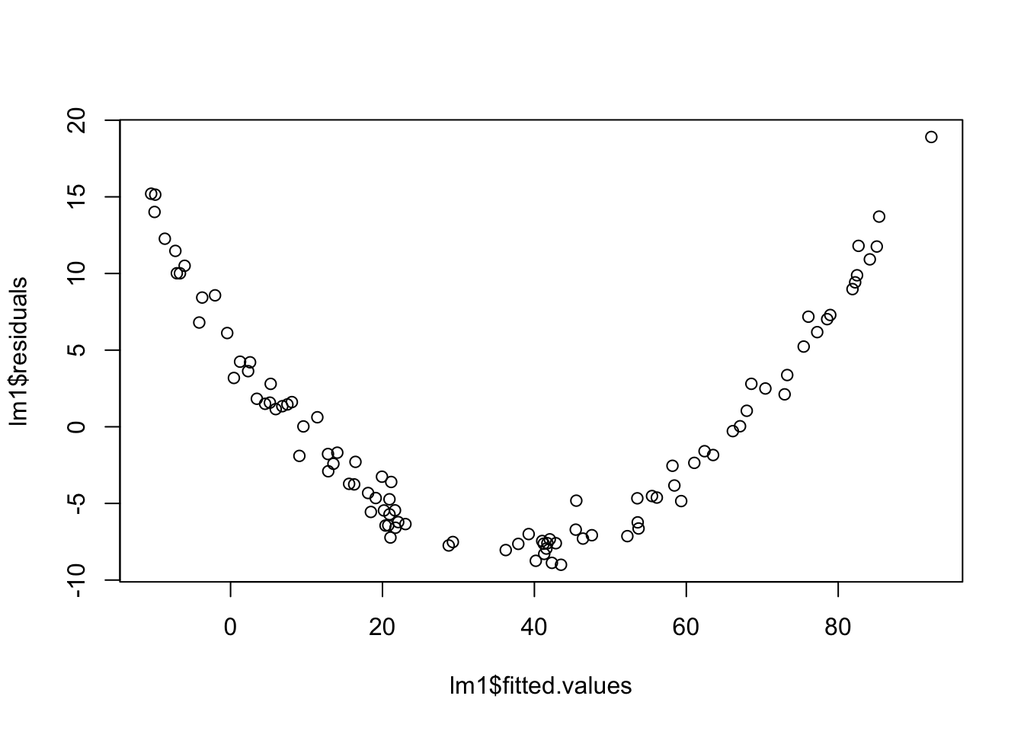

```r
plot(lm1$fitted.values, lm1$residuals)
```

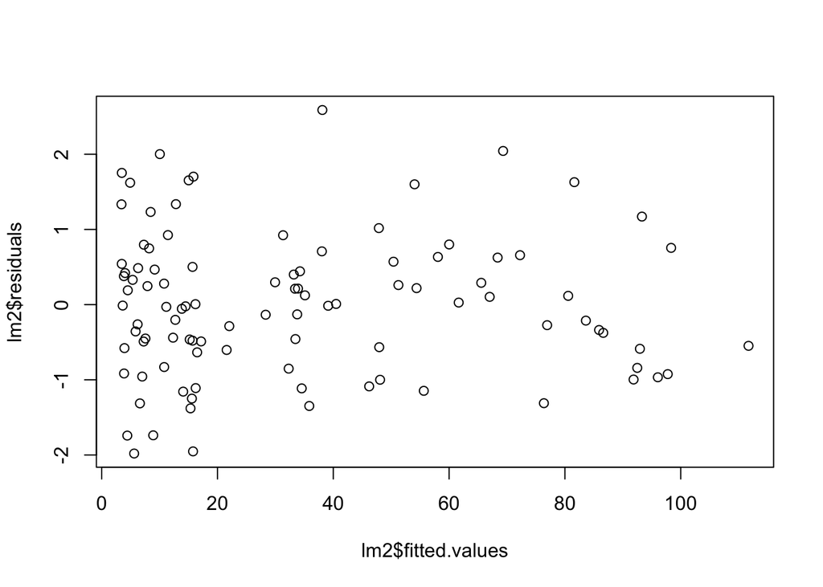

```r
plot(lm2$fitted.values, lm2$residuals)
```

There is a strong curved parabola shape shown in the plot for the first model, suggesting that the assumption of linearity is violated for this model and thus that the second model may be a better fit since it includes the $x^2$ term.

## part (c)

Which model is better? Give your reason.

The second model is better for estimating y because it does not appear to violate the assumption of linearity as the first model does and it instead includes the $x^2$ term which fits the shape that can be seen in the plot of the residuals versus fitted values for model 1.